# Rendu du TP4

FX Jollois

1 avril 2016

## Les données

Nous allons reprendre sur le jeu de données `us_data` disponible dans la librairie `sashelp` de SAS, basé sur les données de l’[US Census 2010](http://www.census.gov/2010census/data/).

```r
us = read.table("US_DATA.csv", header = T)
```

| STATENAME | DENSITY_1910 | DENSITY_1920 | DENSITY_1930 | DENSITY_1940 | DENSITY_1950 | DENSITY_1960 | DENSITY_1970 | DENSITY_1980 | DENSITY_1990 | DENSITY_2000 | DENSITY_2010 | RANK_1910 | RANK_1920 | RANK_1930 | RANK_1940 | RANK_1950 | RANK_1960 | RANK_1970 | RANK_1980 | RANK_1990 | RANK_2000 | RANK_2010 | REPS_1910 | REPS_1920 | REPS_1930 | REPS_1940 | REPS_1950 | REPS_1960 | REPS_1970 | … |
| --- | --- | --- | --- | --- | --- | --- | --- | --- | --- | --- | --- | --- | --- | --- | --- | --- | --- | --- | --- | --- | --- | --- | --- | --- | --- | --- | --- | --- | --- | --- |
| Alabama | 42.2 | 46.4 | 52.3 | 55.9 | 60.5 | 64.5 | 6.8 | 76.9 | 79.8 | 87.8 | 94.4 | 25 | 25 | 24 | 23 | 24 | 28 | 28 | 28 | 27 | 28 | 29 | 10 | 10 | 9 | 9 | 9 | 8 | 7 | … |
| Alaska | 0.1 | 0.1 | 0.1 | 0.1 | 0.2 | 0.4 | 0.5 | 0.7 | 0.1 | 1.1 | 1.2 | 52 | 52 | 52 | 52 | 52 | 52 | 52 | 52 | 52 | 52 | 52 | NA | NA | NA | NA | NA | 1 | 1 | … |
| Arizona | 1.8 | 2.9 | 3.8 | 4.4 | 6.6 | 11.5 | 15.6 | 23.9 | 32.3 | 45.2 | 56.3 | 49 | 49 | 47 | 47 | 47 | 43 | 43 | 42 | 39 | 38 | 35 | NA | NA | 1 | 2 | 2 | 3 | 4 | … |
| Arkansas | 30.3 | 33.7 | 35.6 | 37.5 | 36.7 | 34.3 | 3.7 | 43.9 | 45.2 | 51.4 | 5.6 | 30 | 31 | 32 | 32 | 34 | 36 | 37 | 37 | 37 | 36 | 36 | 7 | 7 | 7 | 7 | 6 | 4 | 4 | … |
| California | 15.3 | 2.2 | 36.4 | 44.3 | 6.8 | 100.9 | 128.1 | 151.9 | 19.1 | 217.4 | 239.1 | 38 | 35 | 31 | 30 | 22 | 15 | 15 | 16 | 14 | 14 | 13 | 11 | 11 | 20 | 23 | 30 | 38 | 43 | … |
| Colorado | 7.7 | 9.1 | 1.0 | 10.8 | 12.8 | 16.9 | 21.3 | 27.9 | 31.8 | 41.5 | 48.5 | 42 | 42 | 41 | 42 | 42 | 42 | 41 | 40 | 40 | 39 | 39 | 4 | 4 | 4 | 4 | 4 | 4 | 5 | … |

## Analyser les états en fonction de leur population

On se retreint ici aux variables `POPULATION_xxx`. Nous créons un `data.frame` spécifique.

```r
us_pop = us[grep("POPULATION", names(us))]
rownames(us_pop) = us$STATENAME
```

|  | POPULATION_1910 | POPULATION_1920 | POPULATION_1930 | POPULATION_1940 | POPULATION_1950 | POPULATION_1960 | POPULATION_1970 | POPULATION_1980 | POPULATION_1990 | POPULATION_2000 | POPULATION_2010 |
| --- | --- | --- | --- | --- | --- | --- | --- | --- | --- | --- | --- |
| Alabama | 2138093 | 2348174 | 2646248 | 2832961 | 3061743 | 3266740 | 3444165 | 3893888 | 4040587 | 4447100 | 4779736 |
| Alaska | 64356 | 55036 | 59278 | 72524 | 128643 | 226167 | 300382 | 401851 | 550043 | 626932 | 710231 |
| Arizona | 204354 | 334162 | 435573 | 499261 | 749587 | 1302161 | 1770900 | 2718215 | 3665228 | 5130632 | 6392017 |
| Arkansas | 1574449 | 1752204 | 1854482 | 1949387 | 1909511 | 1786272 | 1923295 | 2286435 | 2350725 | 2673400 | 2915918 |
| California | 2377549 | 3426861 | 5677251 | 6907387 | 10586223 | 15717204 | 19953134 | 23667902 | 29760021 | 33871648 | 37253956 |
| Colorado | 799024 | 939629 | 1035791 | 1123296 | 1325089 | 1753947 | 2207259 | 2889964 | 3294394 | 4301261 | 5029196 |

### d’une ACP (essayer avec standardisation et sans)

#### Avec standardisation

La fonction `PCA()` du package `FactoMineR` exécute directement une ACP sur les données standardisées. Nous n’avons rien d’autres à spécifier.

```r
acp1 = PCA(us_pop, graph = FALSE)
```

Comme le montre le graphique ci-dessous, seules les deux premières dimensions sont à utiliser (contenant plus de 99.5 % de l’information).

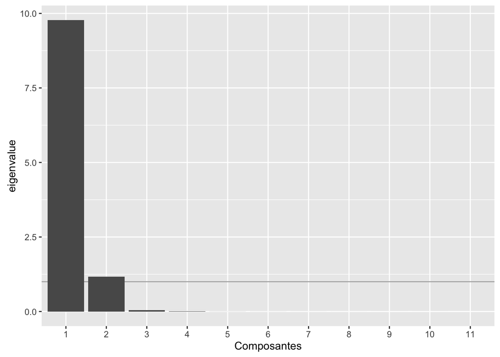

Valeurs propres

Nous voyons quelques états se détachant (les 5 plus peuplés en moyenne).

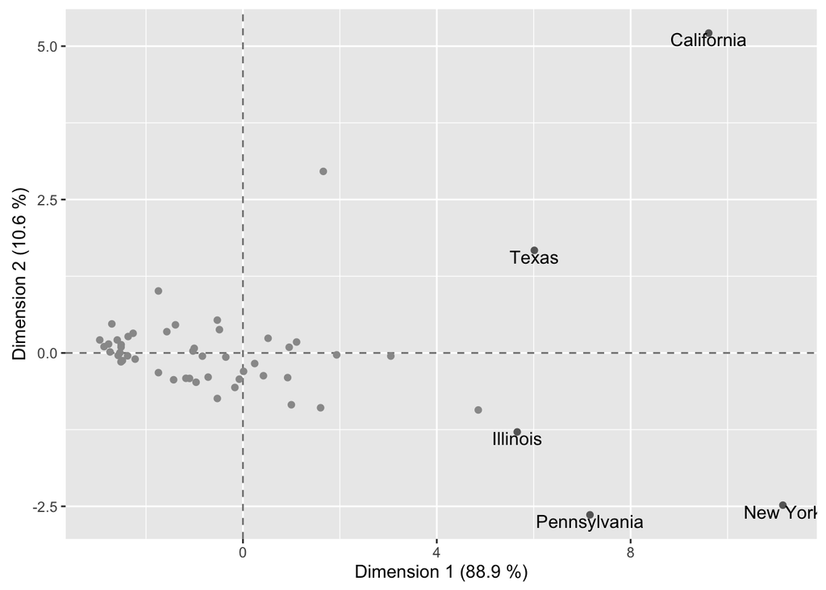

Représentation des états

Ici, nous voyons un effet *Guttman*, avec les années correctement ordonnées sur l’axe 2.

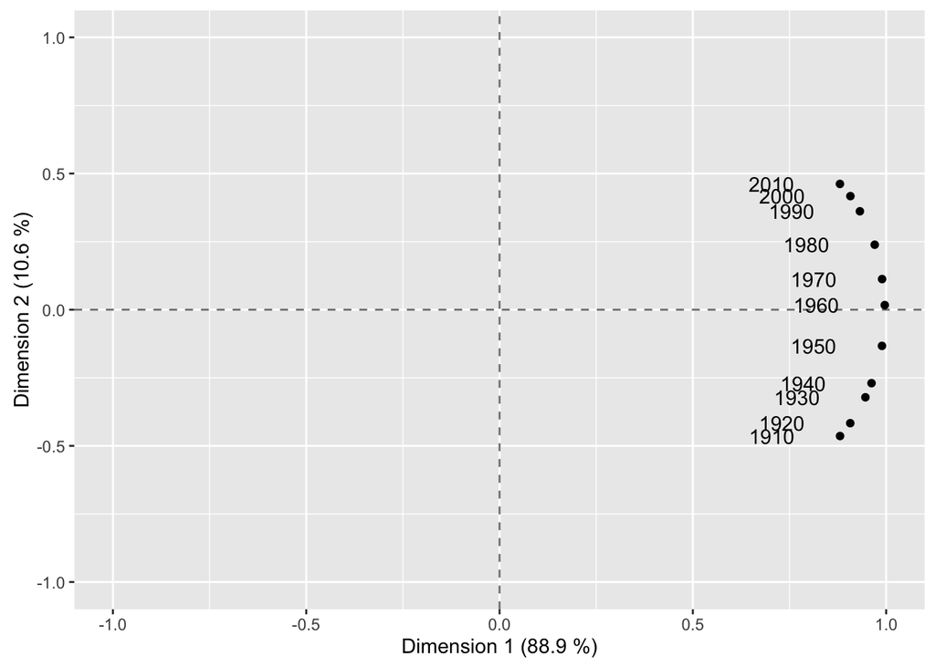

Représentation des années

Si nous regardons les évolutions sur le siècle dernier (cf figure ci-après), nous voyons que la Californie, et le Texas sont les états ayant le plus progressés en population sur la période analysée.

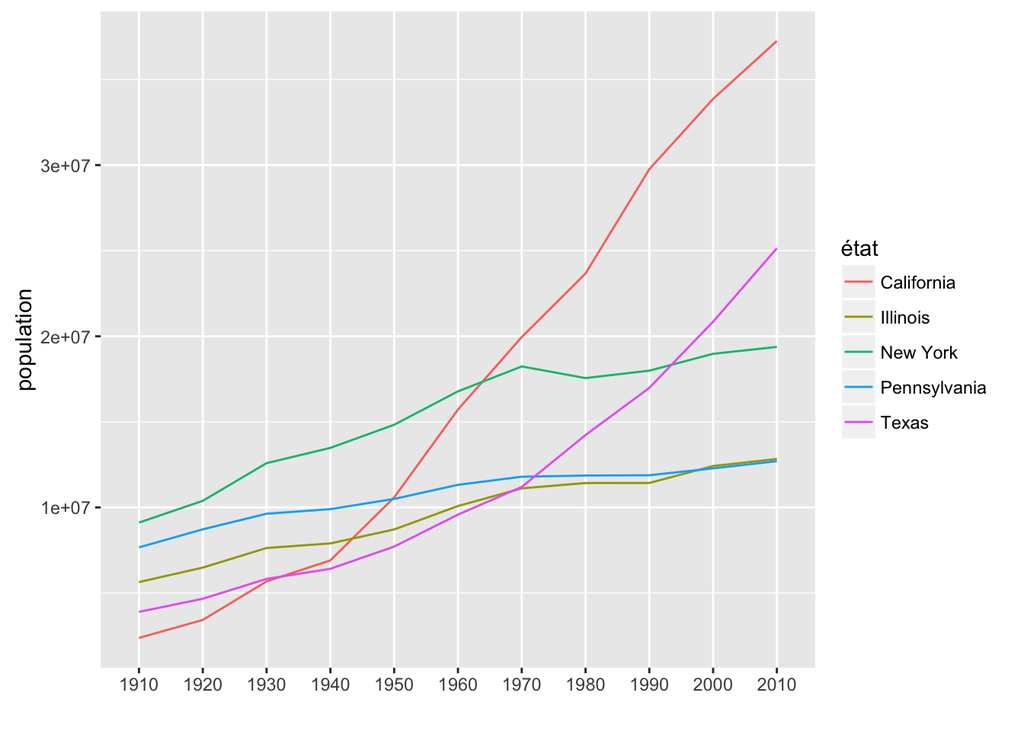

#### Sans standardisation

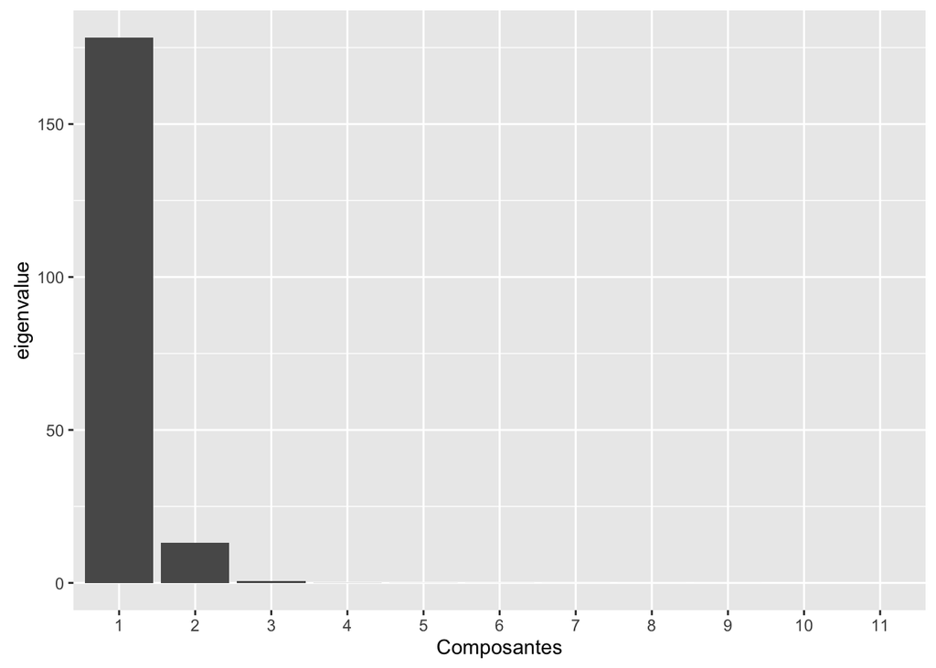

Valeurs propres

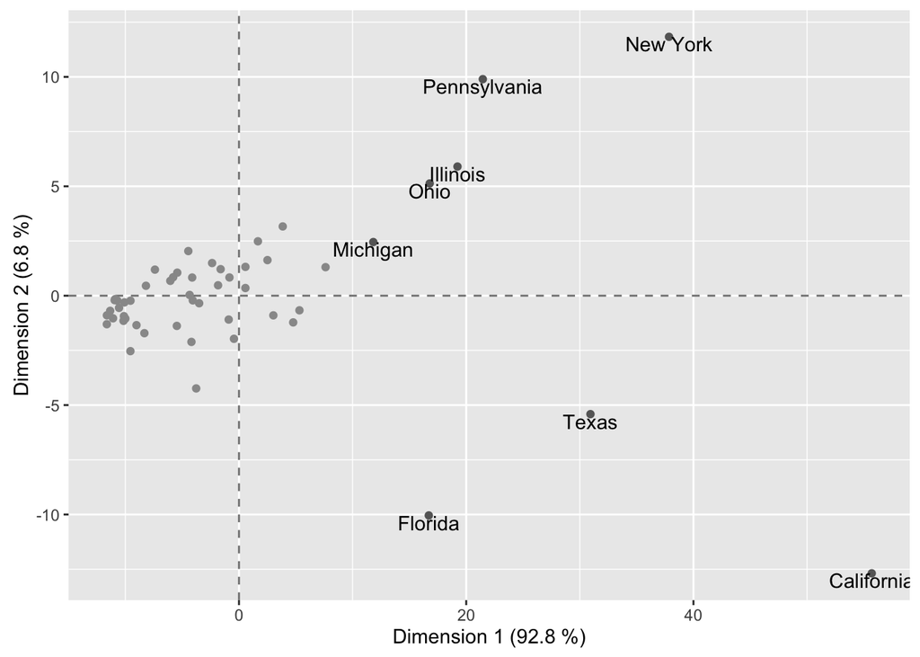

Représentation des états

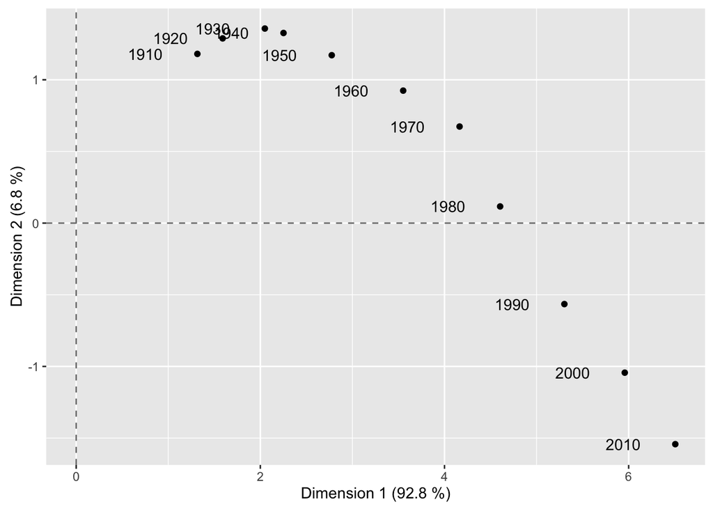

Représentation des années

```r
acp2 = PCA(us_pop / 1000000, graph = FALSE, scale.unit = FALSE)
```

### d’une AFC

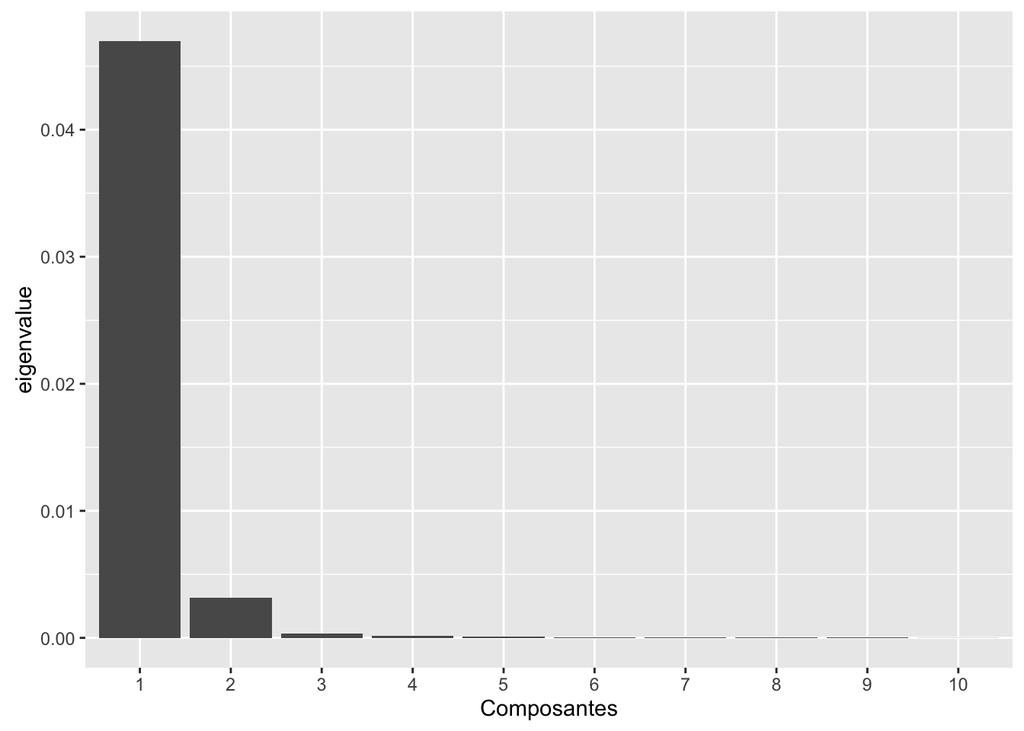

Valeurs propres

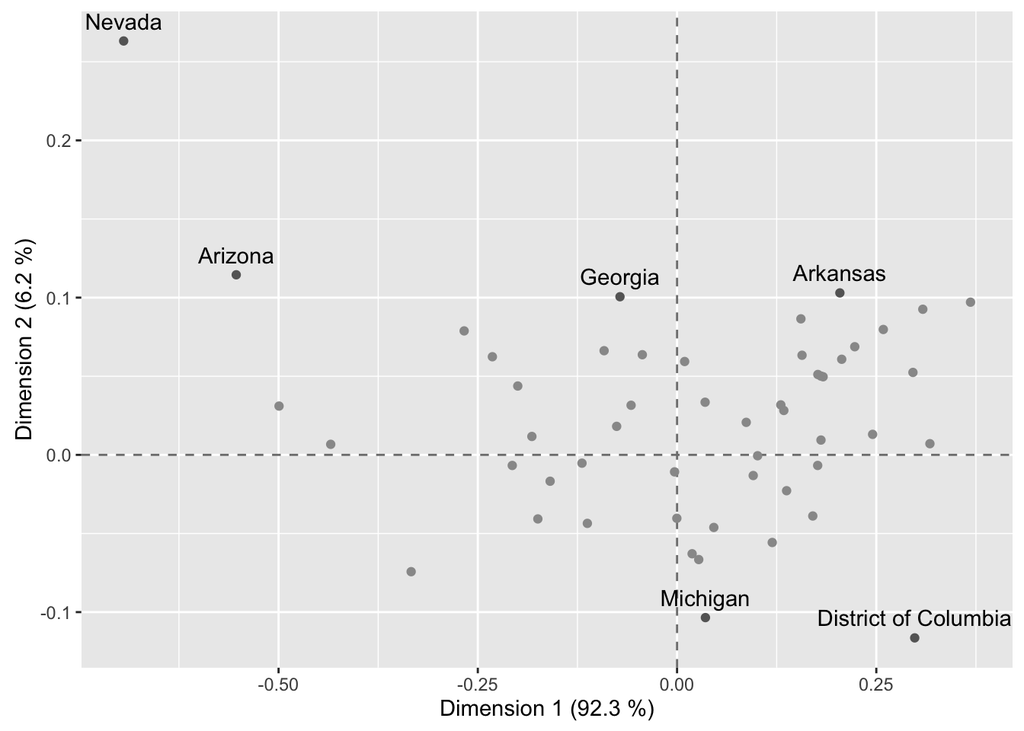

Représentation des états

[figure not shown]

Représentation des années

```r
afc = CA(us_pop, graph = FALSE)
```

## Faire de même pour la densité (variables DENSITY_xxxx)

A faire

## Faire une partition en un nombre de classes adapté sur chaque ensemble de données précédent

### Choisir le nombre de classes à l’aide de la CAH et de $k$-means (avec $r^2$ et $PseudoF$)

#### Avec la CAH

On regarde déjà avec la CAH, qui nous propose ici un découpage en 2 classes, voire en 4 classes.

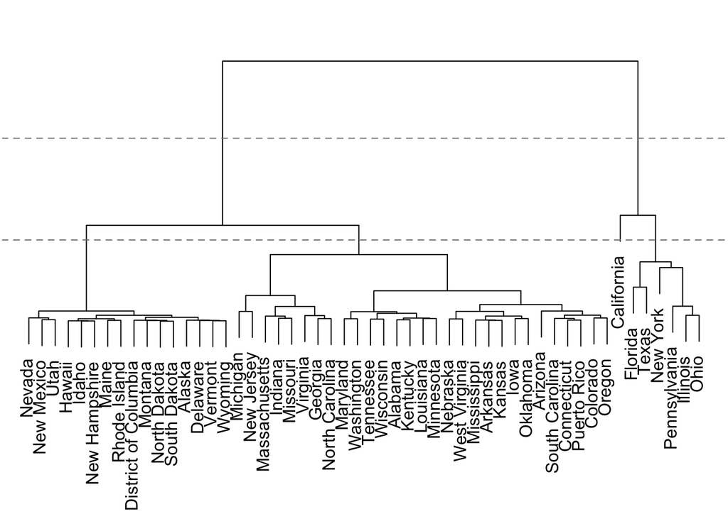

Ce qui revient aux deux découpages suivant

```
## [[1]]
##  [1] "Alabama"              "Alaska"               "Arizona"
##  [4] "Arkansas"             "Colorado"             "Connecticut"
##  [7] "Delaware"             "District of Columbia" "Georgia"
## [10] "Hawaii"               "Idaho"                "Indiana"
## [13] "Iowa"                 "Kansas"               "Kentucky"
## [16] "Louisiana"            "Maine"                "Maryland"
## [19] "Massachusetts"        "Michigan"             "Minnesota"
## [22] "Mississippi"          "Missouri"             "Montana"
## [25] "Nebraska"             "Nevada"               "New Hampshire"
## [28] "New Jersey"           "New Mexico"           "North Carolina"
## [31] "North Dakota"         "Oklahoma"             "Oregon"
## [34] "Puerto Rico"          "Rhode Island"         "South Carolina"
## [37] "South Dakota"         "Tennessee"            "Utah"
## [40] "Vermont"              "Virginia"             "Washington"
## [43] "West Virginia"        "Wisconsin"            "Wyoming"
##
## [[2]]
## [1] "California"   "Florida"      "Illinois"     "New York"
## [5] "Ohio"         "Pennsylvania" "Texas"
```

```
## [[1]]
##  [1] "Alabama"        "Arizona"        "Arkansas"       "Colorado"
##  [5] "Connecticut"    "Georgia"        "Indiana"        "Iowa"
##  [9] "Kansas"         "Kentucky"       "Louisiana"      "Maryland"
## [13] "Massachusetts"  "Michigan"       "Minnesota"      "Mississippi"
## [17] "Missouri"       "Nebraska"       "New Jersey"     "North Carolina"
## [21] "Oklahoma"       "Oregon"         "Puerto Rico"    "South Carolina"
## [25] "Tennessee"      "Virginia"       "Washington"     "West Virginia"
## [29] "Wisconsin"
##
## [[2]]
##  [1] "Alaska"               "Delaware"             "District of Columbia"
##  [4] "Hawaii"               "Idaho"                "Maine"
##  [7] "Montana"              "Nevada"               "New Hampshire"
## [10] "New Mexico"           "North Dakota"         "Rhode Island"
## [13] "South Dakota"         "Utah"                 "Vermont"
## [16] "Wyoming"
##
## [[3]]
## [1] "California"
##
## [[4]]
## [1] "Florida"      "Illinois"     "New York"     "Ohio"
## [5] "Pennsylvania" "Texas"
```

#### Avec $k$-means

On teste ensuite $k$-means, entre 1 et 9 classes

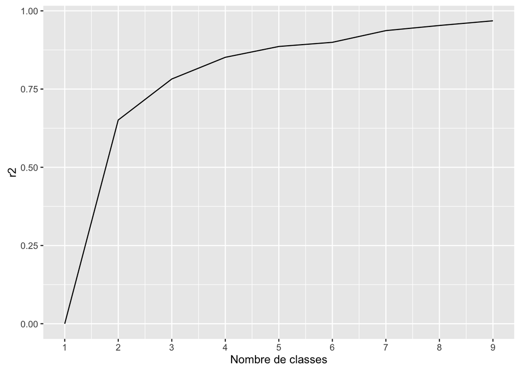

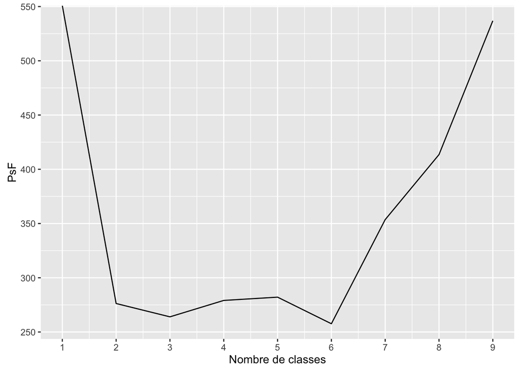

```
## [[1]]
##  [1] "Alabama"              "Alaska"               "Arizona"
##  [4] "Arkansas"             "Colorado"             "Connecticut"
##  [7] "Delaware"             "District of Columbia" "Florida"
## [10] "Georgia"              "Hawaii"               "Idaho"
## [13] "Indiana"              "Iowa"                 "Kansas"
## [16] "Kentucky"             "Louisiana"            "Maine"
## [19] "Maryland"             "Massachusetts"        "Minnesota"
## [22] "Mississippi"          "Missouri"             "Montana"
## [25] "Nebraska"             "Nevada"               "New Hampshire"
## [28] "New Jersey"           "New Mexico"           "North Carolina"
## [31] "North Dakota"         "Oklahoma"             "Oregon"
## [34] "Puerto Rico"          "Rhode Island"         "South Carolina"
## [37] "South Dakota"         "Tennessee"            "Utah"
## [40] "Vermont"              "Virginia"             "Washington"
## [43] "West Virginia"        "Wisconsin"            "Wyoming"
##
## [[2]]
## [1] "California"   "Illinois"     "Michigan"     "New York"
## [5] "Ohio"         "Pennsylvania" "Texas"
```

```
## [[1]]
##  [1] "Alabama"    "Iowa"       "Kentucky"   "Louisiana"  "Maryland"
##  [6] "Minnesota"  "Tennessee"  "Virginia"   "Washington" "Wisconsin"
##
## [[2]]
## [1] "Illinois"     "Ohio"         "Pennsylvania" "Texas"
##
## [[3]]
##  [1] "Arkansas"       "Colorado"       "Connecticut"    "Kansas"
##  [5] "Mississippi"    "Nebraska"       "Oklahoma"       "Oregon"
##  [9] "Puerto Rico"    "South Carolina" "West Virginia"
##
## [[4]]
## [1] "Georgia"        "Indiana"        "Massachusetts"  "Michigan"
## [5] "Missouri"       "New Jersey"     "North Carolina"
##
## [[5]]
## [1] "California"
##
## [[6]]
## [1] "Florida"
##
## [[7]]
##  [1] "Alaska"               "Arizona"              "Delaware"
##  [4] "District of Columbia" "Hawaii"               "Idaho"
##  [7] "Maine"                "Montana"              "Nevada"
## [10] "New Hampshire"        "New Mexico"           "North Dakota"
## [13] "Rhode Island"         "South Dakota"         "Utah"
## [16] "Vermont"              "Wyoming"
##
## [[8]]
## [1] "New York"
```

### Prendre la partition obtenue avec $k$-means (et le nombre de classes choisi)

On conserve la partition en 2 classes.

On peut décrire ces classes par leur population moyenne par année.

| POPULATION_1910 | POPULATION_1920 | POPULATION_1930 | POPULATION_1940 | POPULATION_1950 | POPULATION_1960 | POPULATION_1970 | POPULATION_1980 | POPULATION_1990 | POPULATION_2000 | POPULATION_2010 |
| --- | --- | --- | --- | --- | --- | --- | --- | --- | --- | --- |
| 1268396 | 1426955 | 1597900 | 1717153 | 1930674 | 2236965 | 2535603 | 2909712 | 3200895 | 3678637 | 4083123 |
| 5181243 | 6158346 | 7548723 | 8108927 | 9522313 | 11572757 | 13117402 | 14115041 | 15455949 | 17098837 | 18390111 |

Nous voyons dans le graphique ci-dessous qu’une classe correspond aux états à forte population, et l’autre à plus faible population.

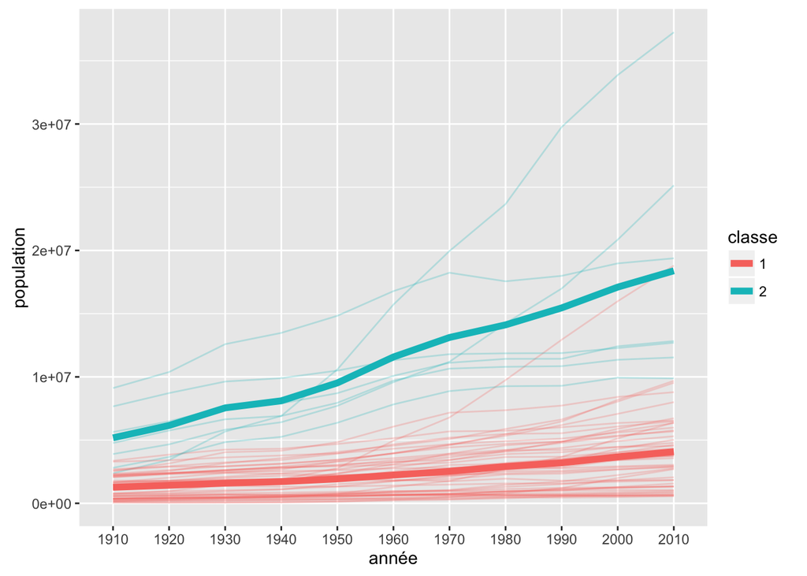

Il pourrait être intéressant de travailler sur les évolutions en base 100 en 1910, plutôt que sur les populations directement. On analyserait ainsi les évolutions plutôt que les ordres de grandeur.

Voila la représentation des évolutions de tous les états en base 100 en 1910, dans laquelle nous voyons que certains états évoluent très fortement (population multipliée par 30).

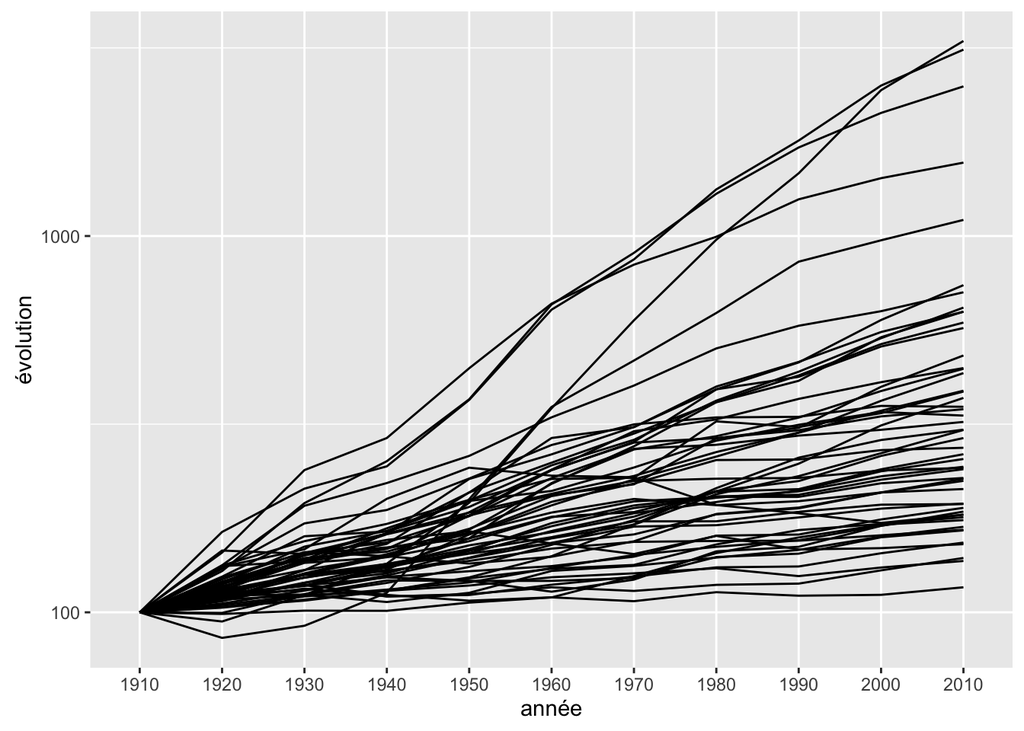

### Comparer les deux partitions obtenues entre elles, et avec les régions et les divisions présentes dans les données

Dans un premier temps, on regarde comment les états des divisions se répartissent dans les classes.

|  | 1 | 2 |
| --- | --- | --- |
| East North Central | 2 | 3 |
| East South Central | 4 | 0 |
| Middle Atlantic | 1 | 2 |
| Mountain | 8 | 0 |
| New England | 6 | 0 |
| Pacific | 4 | 1 |
| South Atlantic | 10 | 0 |
| West North Central | 7 | 0 |
| West South Central | 3 | 1 |

Et on fait de même pour les régions.

|  | 1 | 2 |
| --- | --- | --- |
| Midwest | 9 | 3 |
| Northeast | 7 | 2 |
| South | 17 | 1 |
| West | 12 | 1 |